# InfoViz with R

Haad Khan  
12th March 2015

### Introduction

This presentation is about visualizing data with R

- We are going to use R package ggplot2
- We will talk about some principles of Information Visualization.

-Adapted from Dawn Koffman Office of Population Research Princeton University

### R Package ggplot2

[figure not shown]

- Authored by Hadley Wickham.
- Based on The Grammar of Graphics by Leland Wilkinson, 2005

### qplot()

ggplot2 provides two ways to produce plot objects:

- qplot() #quick plot Not covered in this presentation
- borrows some concepts from graphics of grammer but limited in capability
- very easy to produce basic graphs
- ggplot() grammar of graphics
- has a steeper learning curve but extremely powerful

### Grammar Defines Components of Graphics

data: in ggplot2, data must be stored as an R data frame

coordinate system: decribes 2-D space that data is projected onto

geoms: describe type of geometric objects that represent data

aesthetics: describe visual characteristics that represent data

scales: for each aesthetic, describe how visual characteristic is converted to display values

stats: describe statistical transformations that typically summarize data

facets: describe how data is split into subsets and displayed as multiple small graphs

### First Dive into ggplot2

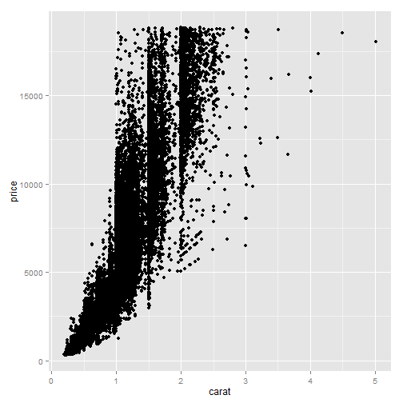

```r
#install.packages("ggplot2")
library(ggplot2)
ggplot(diamonds, aes(x=carat, y=price)) + geom_point()
```

### Creating a Line Graph

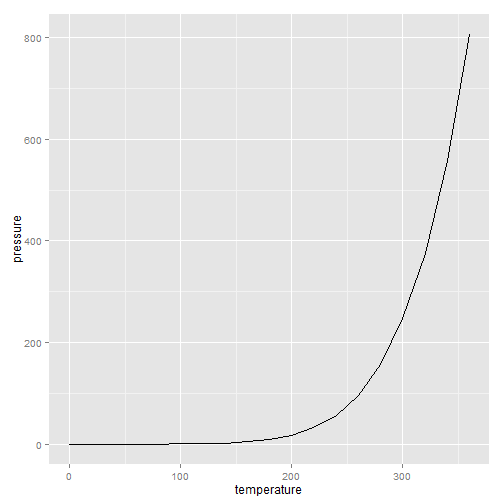

```r
ggplot(pressure, aes(x=temperature, y=pressure)) + geom_line()
```

### Diamond Smoothing

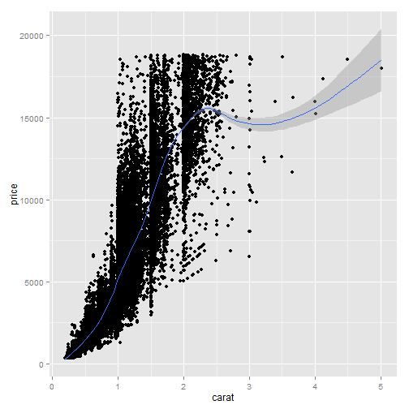

```r
ggplot(diamonds,aes(x=carat, y=price))+ geom_point()+ stat_smooth()
```

### Diamond Smoothing Zooming

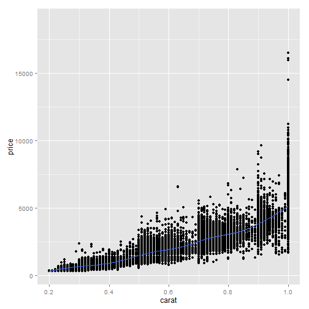

```r
ggplot(diamonds,aes(x=carat, y=price))+ geom_point()+ stat_smooth()+xlim(0.2,1)
```

### Diamond Smoothing Zooming Jitter

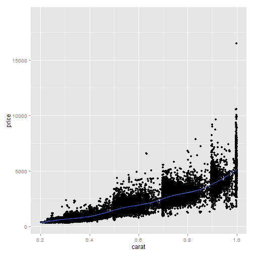

```r
ggplot(diamonds,aes(x=carat, y=price))+ geom_jitter()+ stat_smooth()+xlim(0.2,1)
```

### Diamond Smoothing Zooming Polygon

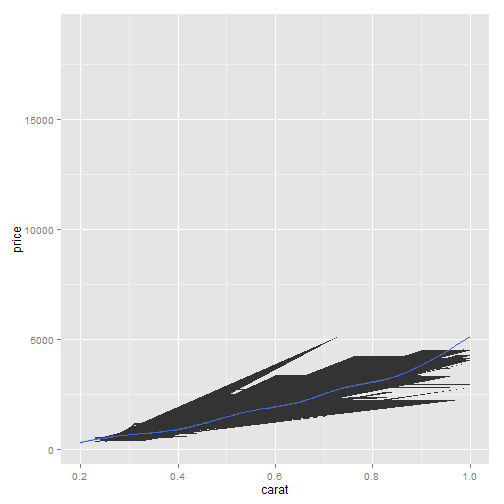

```r
ggplot(diamonds,aes(x=carat, y=price))+ geom_polygon()+ stat_smooth()+xlim(0.2,1)
```

### Diamond Smoothing Zooming Label

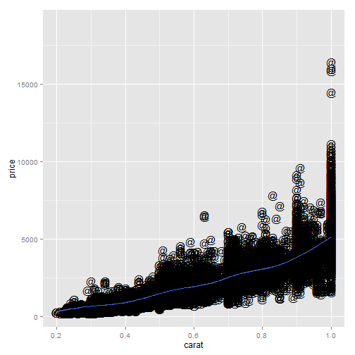

```r
ggplot(diamonds,aes(x=carat, y=price))+ geom_text(label = '@')+ stat_smooth()+xlim(0.2,1)
```